# Proyek PSD Minggu 4

# libraries

```r
library(readxl)   # baca file excel
library(dplyr)    # olah data
```

```r
library(tidyr)    # rapikan data (pivot dll)
library(ggplot2)  # visualisasi
library(corrplot) # heatmap korelasi
library(skimr)    # ringkasan data cepat & lengkap
library(scales)   # untuk skala
```

# Input Data

```r
data <- read_xlsx("C:\\Users\\Aquila\\Downloads\\PSD_DATA_MOBIL_JAKARTA_FINAL_CLEAN.xlsx")
data
```

```
## # A tibble: 3,485 × 26
##    Judul       URL_Detail Kategori Provinsi Kota_Kabupaten Kecamatan Merk  Model
##    <chr>       <chr>      <chr>    <chr>    <chr>          <chr>     <chr> <chr>
##  1 [ GARANSI … https://w… Mobil B… Jakarta… Jakarta Barat  Jakarta … Hyun… Pali…
##  2 Honda Acco… https://w… Mobil B… Jakarta… Jakarta Selat… Jakarta … Honda Acco…
##  3 [ VIP 2+2 … https://w… Mobil B… Jakarta… Jakarta Barat  Jakarta … Lexus LM35…
##  4 KM LOW 25R… https://w… Mobil B… Jakarta… Jakarta Selat… Jakarta … Toyo… Kija…
##  5 TOYOTA AGY… https://w… Mobil B… Jakarta… Jakarta Selat… Jakarta … Toyo… Agya
##  6 Mitsubishi… https://w… Mobil B… Jakarta… Jakarta Timur  Jakarta … Mits… Xpan…
##  7 BMW 320i 2… https://w… Mobil B… Jakarta… Jakarta Selat… Jakarta … BMW   320i
##  8 2019 Merce… https://w… Mobil B… Jakarta… Jakarta Selat… Jakarta … Merc… E350
##  9 Mercedes B… https://w… Mobil B… Jakarta… Jakarta Selat… Jakarta … Merc… C200
## 10 [ GARANSI … https://w… Mobil B… Jakarta… Jakarta Selat… Jakarta … Honda Acco…
## # ℹ 3,475 more rows
## # ℹ 18 more variables: Brand_Tier <chr>, Tahun <dbl>, Usia_Mobil <dbl>,
## #   Harga_IDR <dbl>, Jarak_Tempuh_KM <dbl>, Odometer_Group <chr>,
## #   Kapasitas_Mesin_CC <dbl>, Tipe_Bahan_Bakar <chr>, Transmisi <chr>,
## #   Tipe_Bodi <chr>, Warna <chr>, Tipe_Penjual <chr>, Nama_Bursa_Mobil <chr>,
## #   Is_Garansi <lgl>, Is_KM_Low <lgl>, Is_Facelift <lgl>, Is_Sport_Trim <lgl>,
## #   Is_Promo_DP <lgl>
```

# Eksplorasi Data

```r
dim(data) # Cek dimensi
```

```
## [1] 3485   26
```

```r
str(data) # Cek struktur/tipe data
```

```
## tibble [3,485 × 26] (S3: tbl_df/tbl/data.frame)
##  $ Judul             : chr [1:3485] "[ GARANSI 5TH ] Hyundai Palisade Signature 2.2 Panoramic AT 2023/2024" "Honda Accord VTI 2.4 AT 2008 Abu ab PAJAK PANJANG" "[ VIP 2+2 ] Lexus LM350 LM 350 Hybrid Executive 4 Seater 2025/2026" "KM LOW 25RB !! TOYOTA INNOVA ZENIX G BENSIN 2023 AT MDL 2024/2025" …
##  $ URL_Detail        : chr [1:3485] "https://www.olx.co.id/item/947162566" "https://www.olx.co.id/item/947836080" "https://www.olx.co.id/item/945930945" "https://www.olx.co.id/item/947711670" ...
##  $ Kategori          : chr [1:3485] "Mobil Bekas" "Mobil Bekas" "Mobil Bekas" "Mobil Bekas" ...
##  $ Provinsi          : chr [1:3485] "Jakarta D.K.I." "Jakarta D.K.I." "Jakarta D.K.I." "Jakarta D.K.I." ...
##  $ Kota_Kabupaten    : chr [1:3485] "Jakarta Barat" "Jakarta Selatan" "Jakarta Barat" "Jakarta Selatan" ...
##  $ Kecamatan         : chr [1:3485] "Jakarta Barat" "Jakarta Selatan" "Jakarta Barat" "Jakarta Selatan" ...
##  $ Merk              : chr [1:3485] "Hyundai" "Honda" "Lexus" "Toyota" ...
##  $ Model             : chr [1:3485] "Palisade" "Accord" "LM350h" "Kijang Innova" ...
##  $ Brand_Tier        : chr [1:3485] "Mass Market" "Mass Market" "Luxury" "Mass Market" ...
##  $ Tahun             : num [1:3485] 2023 2008 2025 2023 2023 ...
##  $ Usia_Mobil        : num [1:3485] 3 18 1 3 3 7 10 7 9 5 ...
##  $ Harga_IDR         : num [1:3485] 6.62e+08 9.80e+07 2.25e+09 3.10e+08 1.40e+08 1.86e+08 2.99e+08 5.99e+08 3.35e+08 3.75e+08 ...
##  $ Jarak_Tempuh_KM   : num [1:3485] 32500 102500 7500 22500 22500 ...
##  $ Odometer_Group    : chr [1:3485] "20k-50k (Low)" ">100k (Tinggi)" "<20k (Sangat Low)" "20k-50k (Low)" ...
##  $ Kapasitas_Mesin_CC: num [1:3485] 2200 2400 2500 1750 1750 1750 1750 1750 1750 1500 ...
##  $ Tipe_Bahan_Bakar  : chr [1:3485] "Diesel" "Bensin" "Hybrid" "Bensin" ...
##  $ Transmisi         : chr [1:3485] "Automatic" "Automatic" "Automatic" "Automatic" ...
##  $ Tipe_Bodi         : chr [1:3485] "SUV" "Sedan" "MPV" "MPV" ...
##  $ Warna             : chr [1:3485] "Hitam" "Abu-abu" "Abu-abu" "Hitam" ...
##  $ Tipe_Penjual      : chr [1:3485] "Diler" "Diler" "Diler" "Diler" ...
##  $ Nama_Bursa_Mobil  : chr [1:3485] "Penjual Perorangan" "Penjual Perorangan" "Penjual Perorangan" "Penjual Perorangan" ...
##  $ Is_Garansi        : logi [1:3485] TRUE FALSE FALSE FALSE FALSE FALSE ...
##  $ Is_KM_Low         : logi [1:3485] FALSE FALSE FALSE TRUE FALSE FALSE ...
##  $ Is_Facelift       : logi [1:3485] FALSE FALSE FALSE FALSE FALSE FALSE ...
##  $ Is_Sport_Trim     : logi [1:3485] FALSE FALSE FALSE FALSE FALSE FALSE ...
##  $ Is_Promo_DP       : logi [1:3485] FALSE FALSE FALSE FALSE FALSE FALSE ...
```

```r
sum(is.na(data)) # total missing value di seluruh data
```

```
## [1] 0
```

```r
sum(duplicated(data)) # cek baris duplikat
```

```
## [1] 0
```

```r
summary(data)
```

```
##        Judul          URL_Detail        Kategori         Provinsi
##  Length   :3485   Length   :3485   Length   :3485   Length   :3485
##  N.unique :2772   N.unique :3485   N.unique :   1   N.unique :   8
##  N.blank  :   0   N.blank  :   0   N.blank  :   0   N.blank  :   0
##  Min.nchar:  15   Min.nchar:  36   Min.nchar:  11   Min.nchar:   6
##  Max.nchar:  70   Max.nchar:  36   Max.nchar:  11   Max.nchar:  15
##
##    Kota_Kabupaten     Kecamatan           Merk            Model
##  Length   :3485   Length   :3485   Length   :3485   Length   :3485
##  N.unique :  18   N.unique :  18   N.unique :  54   N.unique : 434
##  N.blank  :   0   N.blank  :   0   N.blank  :   0   N.blank  :   0
##  Min.nchar:  10   Min.nchar:  10   Min.nchar:   2   Min.nchar:   1
##  Max.nchar:  22   Max.nchar:  22   Max.nchar:  13   Max.nchar:  19
##
##      Brand_Tier       Tahun        Usia_Mobil       Harga_IDR
##  Length   :3485   Min.   :1986   Min.   : 0.000   Min.   :3.00e+07
##  N.unique :   4   1st Qu.:2018   1st Qu.: 3.000   1st Qu.:2.15e+08
##  N.blank  :   0   Median :2022   Median : 4.000   Median :4.05e+08
##  Min.nchar:   5   Mean   :2019   Mean   : 6.667   Mean   :6.90e+08
##  Max.nchar:  11   3rd Qu.:2023   3rd Qu.: 8.000   3rd Qu.:6.75e+08
##                   Max.   :2026   Max.   :40.000   Max.   :5.00e+09
##  Jarak_Tempuh_KM    Odometer_Group Kapasitas_Mesin_CC  Tipe_Bahan_Bakar
##  Min.   :     0   Length   :3485   Min.   : 850       Length   :3485
##  1st Qu.: 12500   N.unique :   4   1st Qu.:1500       N.unique :   4
##  Median : 32500   N.blank  :   0   Median :2000       N.blank  :   0
##  Mean   : 46490   Min.nchar:  13   Mean   :2058       Min.nchar:   6
##  3rd Qu.: 62500   Max.nchar:  17   3rd Qu.:2500       Max.nchar:   7
##  Max.   :300000                    Max.   :6200
##      Transmisi        Tipe_Bodi          Warna         Tipe_Penjual
##  Length   :3485   Length   :3485   Length   :3485   Length   :3485
##  N.unique :   2   N.unique :  18   N.unique :  14   N.unique :   2
##  N.blank  :   0   N.blank  :   0   N.blank  :   0   N.blank  :   0
##  Min.nchar:   6   Min.nchar:   3   Min.nchar:   4   Min.nchar:   5
##  Max.nchar:   9   Max.nchar:  18   Max.nchar:   7   Max.nchar:   8
##
##   Nama_Bursa_Mobil Is_Garansi      Is_KM_Low       Is_Facelift
##  Length   :3485    Mode :logical   Mode :logical   Mode :logical
##  N.unique :   1    FALSE:3114      FALSE:2828      FALSE:3318
##  N.blank  :   0    TRUE :371       TRUE :657       TRUE :167
##  Min.nchar:  18
##  Max.nchar:  18
##
##  Is_Sport_Trim   Is_Promo_DP
##  Mode :logical   Mode :logical
##  FALSE:2737      FALSE:3076
##  TRUE :748       TRUE :409
##
##
##
```

## Pola Sebaran

### Tahun

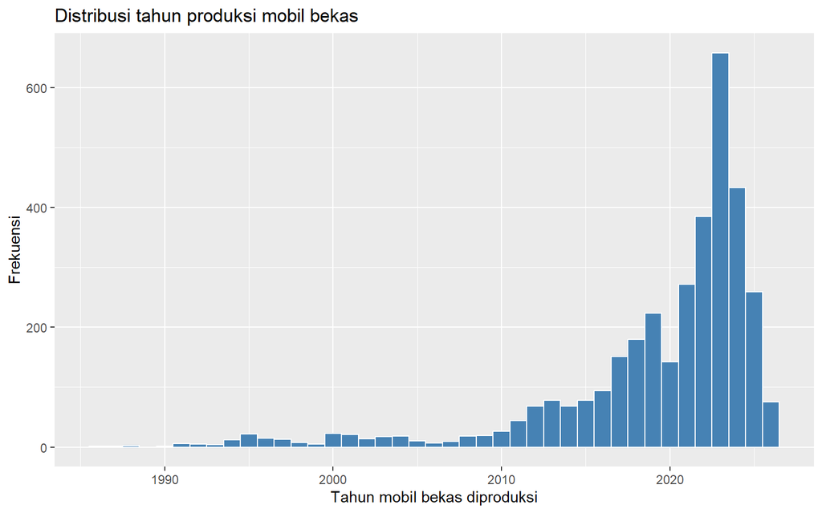

```r
ggplot(data, aes(x = Tahun)) +
  geom_histogram(binwidth = 1, fill = "steelblue", color = "white") +
  labs(title = "Distribusi tahun produksi mobil bekas", x = "Tahun mobil bekas diproduksi", y = "Frekuensi")
```

Distribusi tahun produksi mobil bekas di jakarta bersifat left-skewed, Mobil bekas yang dijual di OLX paling banyak di produksi di sekitar tahun 2021 - 2025, dengan puncak di 2023.

### Harga

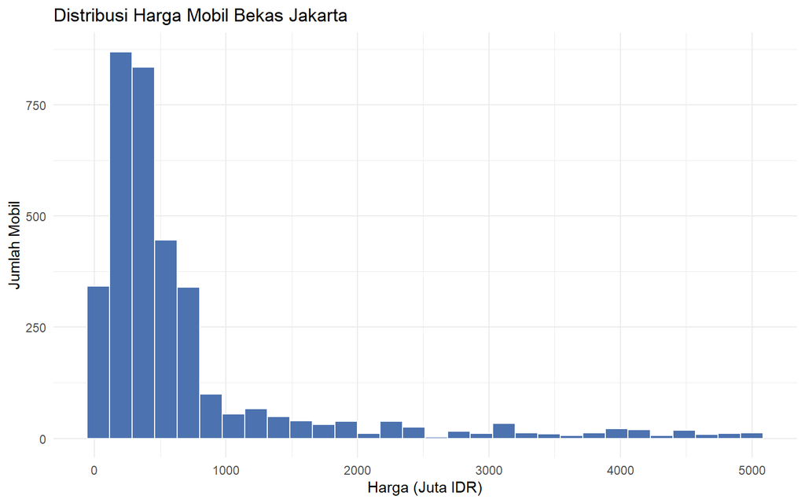

```r
data$Harga_Juta <- data$Harga_IDR / 1e6

ggplot(data, aes(x = Harga_Juta)) +
  geom_histogram(bins = 30, fill = "#4C72B0", color = "white") +
  labs(
    title = "Distribusi Harga Mobil Bekas Jakarta",
    x = "Harga (Juta IDR)",
    y = "Jumlah Mobil"
  ) +
  theme_minimal()
```

Distribusi harga mobil bekas di Jakarta bersifat right-skewed, dengan frekuensi paling besar dari 0 sampai 800 Juta Rupiah

### Jarak Tempuh (KM)

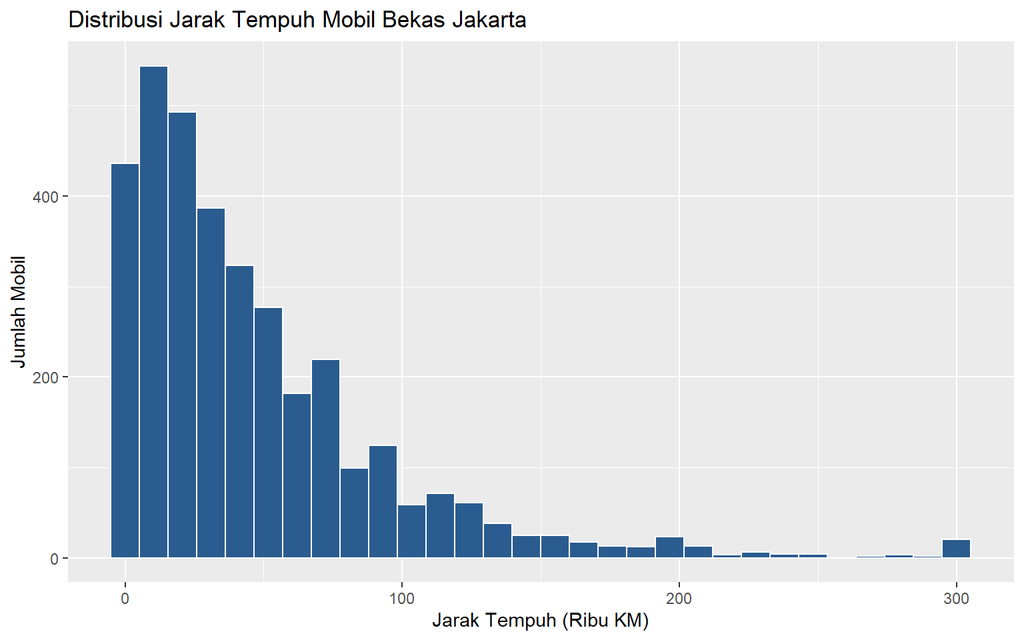

```r
ggplot(data, aes(x = Jarak_Tempuh_KM / 1000)) +
  geom_histogram(bins = 30, fill = "#2b5c8f", color = "white") +
  labs(title = "Distribusi Jarak Tempuh Mobil Bekas Jakarta", x = "Jarak Tempuh (Ribu KM)", y = "Jumlah Mobil")
```

### Kapasitas Mesin (CC)

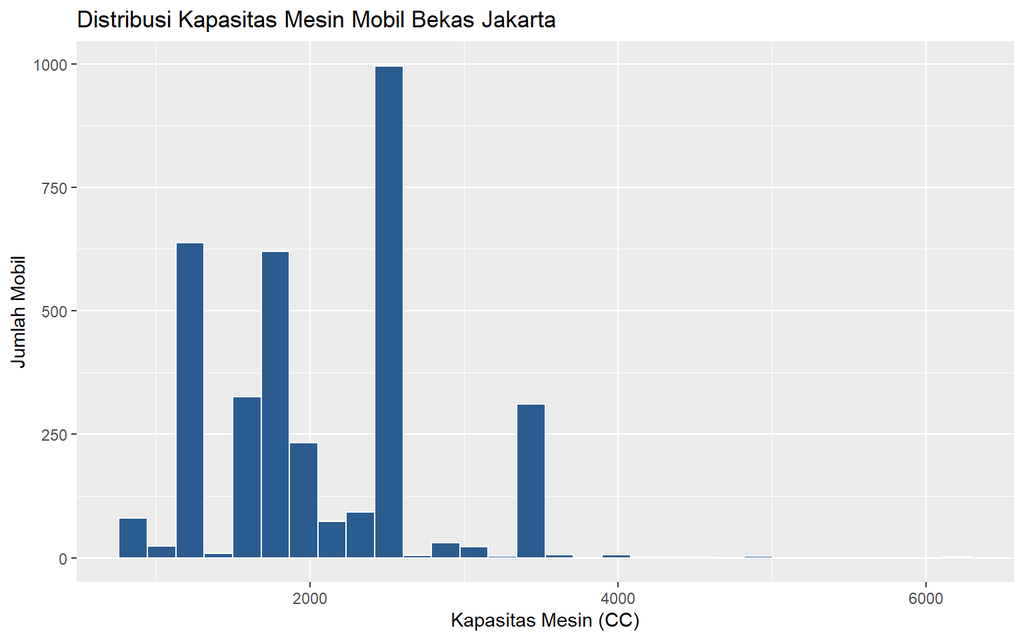

```r
ggplot(data, aes(x = Kapasitas_Mesin_CC)) +
  geom_histogram(bins = 30, fill = "#2b5c8f", color = "white") +
  labs(title = "Distribusi Kapasitas Mesin Mobil Bekas Jakarta", x = "Kapasitas Mesin (CC)", y = "Jumlah Mobil")
```

Distribusi kapasitas mesin mobil bekas di Jakarta memiliki distribusi yang relatif acak dengan modus di 2500 CC

# Visualisasi dan Insights (Boxplot)

## Top 10 Merk vs Harga

```r
# Top 10 merk
top_merk <- data %>%
  group_by(Merk) %>%
  summarise(n = n()) %>%
  top_n(10, n) %>%
  pull(Merk)

data_10merk <- data %>% filter(Merk %in% top_merk)
```

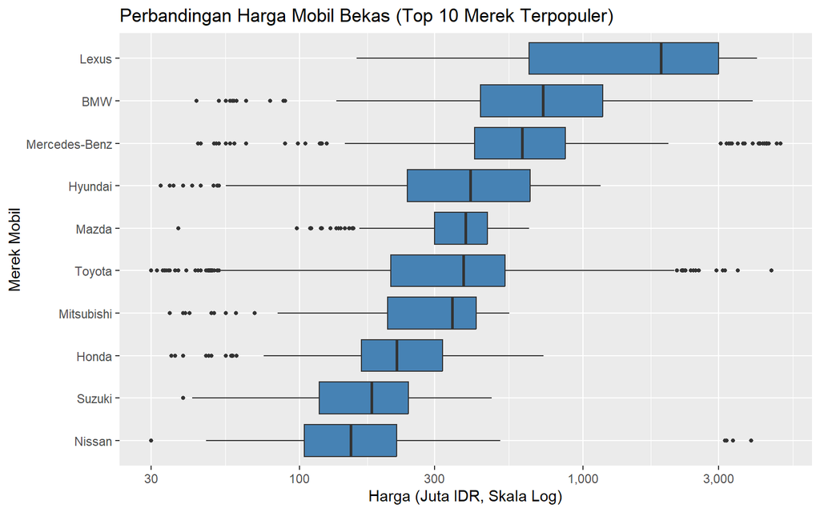

```r
ggplot(data_10merk, aes(x = reorder(Merk, Harga_IDR / 1e6, FUN = median), y = Harga_IDR / 1e6)) +
  geom_boxplot(fill = "steelblue", outlier.size = 1) +
  coord_flip() +
  scale_y_log10(labels = scales::comma) + # Menggunakan skala Log10 karena rentang harga sangat lebar
  labs(
    title = "Perbandingan Harga Mobil Bekas (Top 10 Merek Terpopuler)",
    x = "Merek Mobil",
    y = "Harga (Juta IDR, Skala Log)"
  )
```

Dengan visualisasi boxplot yang diambil dari 10 merek mobil bekas yang paing banyak dijual di daerah Jakarta, kita mendapatkan banyak insight seperti merk Nissan dan Suzuki memiliki harga yang relatif rendah, sebaliknya merk lexus memiliki harga yang paling tinggi. Merk Toyota memiliki sebaran harga yang paling lebar, diikuti dengan merk Mercedes-Benz.

## Warna vs Harga

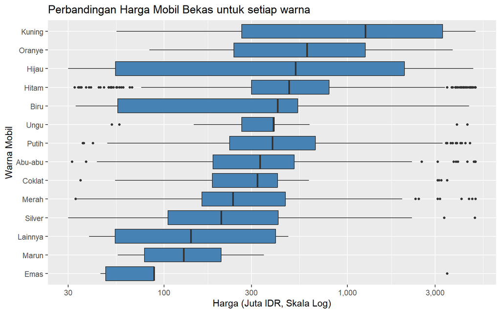

```r
ggplot(data, aes(x = reorder(Warna, Harga_IDR / 1e6, FUN = median), y = Harga_IDR / 1e6)) +
  geom_boxplot(fill = "steelblue", outlier.size = 1) +
  coord_flip() +
  scale_y_log10(labels = scales::comma) + # Menggunakan skala Log10 karena rentang harga sangat lebar
  labs(
    title = "Perbandingan Harga Mobil Bekas untuk setiap warna",
    x = "Warna Mobil",
    y = "Harga (Juta IDR, Skala Log)"
  )
```

Dengan visualisasi boxplot perbandingan warna dan harga, warna kuingn dan oranye memiliki median harga yang paling tinggi. Warna mobil yang monokrom dan umum seperti abu-abu, hitam, dan putih memiliki sebaran harga yang lebar, warna selain monokrom yang juga cukup umum seperti merah dan biru juga memiliki sebaran data yang lebar. Warna emas memiliki harga penjualan yang relatif rendah, mungkin hal ini terjadi karenan memang jumlah mobil bekas berwarna emas yang di OLX sangat sedikit dan kebetulan mobil tersebut dijual dengan harga yang rendah.

## Brand Tier vs Usia mobil

```
## Warning in scale_y_log10(labels = scales::comma): log-10 transformation
## introduced infinite values.
```

```
## Warning: Removed 75 rows containing non-finite outside the scale range
## (`stat_boxplot()`).
```

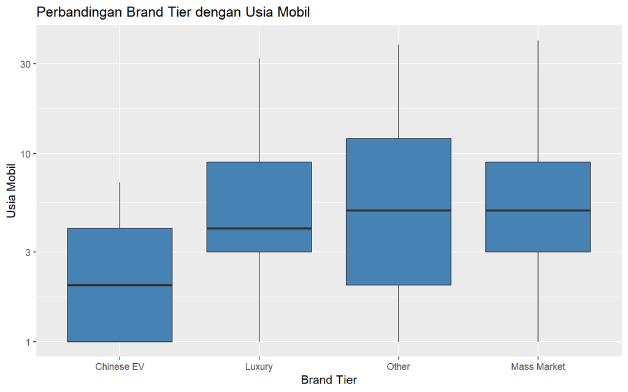

```r
ggplot(data, aes(x = reorder(Brand_Tier, Usia_Mobil, FUN = median), y = Usia_Mobil)) +
  geom_boxplot(fill = "steelblue", outlier.size = 1) +
  scale_y_log10(labels = scales::comma) + # Menggunakan skala Log10 karena rentang harga sangat lebar
  labs(
    title = "Perbandingan Brand Tier dengan Usia Mobil",
    x = "Brand Tier",
    y = "Usia Mobil"
  )
```

## Tipe Penjual VS Jarak Tempuh (KM)

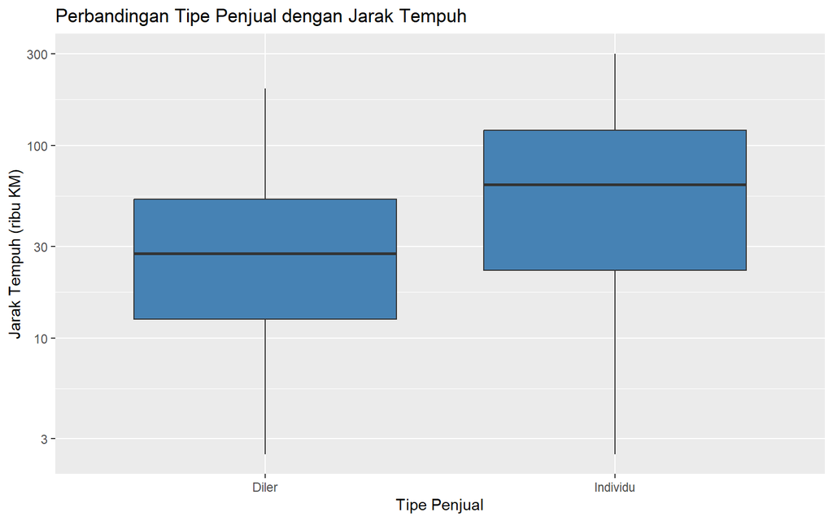

```r
ggplot(data, aes(x = reorder(Tipe_Penjual, Jarak_Tempuh_KM / 1e3, FUN = median), y = Jarak_Tempuh_KM / 1e3)) +
  geom_boxplot(fill = "steelblue", outlier.size = 1) +
  scale_y_log10(labels = scales::comma) + # Menggunakan skala Log10 karena rentang harga sangat lebar
  labs(
    title = "Perbandingan Tipe Penjual dengan Jarak Tempuh",
    x = "Tipe Penjual",
    y = "Jarak Tempuh (ribu KM)")
```

Dengan visualisasi boxplot perbandingan jarak tempuh untuk tipe penjual, dapat diketahui bahwa jarak tempuh individu memiliki median yang lebih besar dibandingkan diler. Sebaran data dalam individu juga terlihat memiliki pola left-skewed.